# Urban Canopy and Temperature

Marc Los Huertos

EA030 · Compiled 2026-10-24

EA030 — Urban Ecology — Field Analysis

# Urban Canopy Cover and Heat Exposure

**Prof. Marc Los Huertos** • Pomona College • Spring 2026

← Back to Project Index

Background P1 · Descriptive P1 · Visualization P1 · Statistics P2 · Descriptive P2 · Visualization P2 · Statistics Synthesis

> **Study overview.** This analysis examines how urban tree canopy cover affects heat exposure across five urban land-use settings and three socioeconomic groups in the Inland Empire. Two complementary instrument types were deployed: **Part I** uses 24-hour infield temperature loggers (continuous air temperature) and **Part II** uses handheld IR thermometers (point-in-time surface temperature). Together they reveal both chronic heat burden and instantaneous thermal conditions.

## Background and Research Context

Urban heat islands (UHIs) emerge when impervious surfaces, reduced vegetation, and waste heat from buildings and vehicles elevate temperatures above surrounding rural areas. Tree canopy provides one of the most cost-effective mitigation strategies — shade reduces incoming radiation while transpiration cools surfaces through latent heat flux.

Environmental justice concerns arise because canopy cover is unevenly distributed: wealthier neighborhoods historically receive more urban greening investment. If canopy reduces heat exposure and low-income communities have less canopy, those communities bear a disproportionate thermal burden.

```r
# ── Set paths — update if your CSVs live elsewhere ───────────────────────────
log_path <- "/home/mwl04747/RTricks/A13_Heat_Islands/Data/infield_logger_canopy_urban.csv"
ir_path  <- "/home/mwl04747/RTricks/A13_Heat_Islands/Data/ir_spot_temperature_canopy_urban.csv"

# ── Part I: infield loggers ───────────────────────────────────────────────────
log_raw <- read_csv(log_path, show_col_types = FALSE) |>
  mutate(
    urban_setting    = factor(urban_setting,    levels = setting_lvl),
    demographic_group = factor(demographic_group, levels = income_lvl)
  )

# ── Part II: IR spot temperatures ────────────────────────────────────────────
ir_raw <- read_csv(ir_path, show_col_types = FALSE) |>
  mutate(
    urban_setting    = factor(urban_setting,    levels = setting_lvl),
    demographic_group = factor(demographic_group, levels = income_lvl),
    time_of_day = cut(measurement_hour,
                      breaks = c(8, 11, 14, 17),
                      labels = c("Morning (9–11)", "Midday (12–14)",
                                 "Afternoon (15–17)"),
                      include.lowest = TRUE)
  )

cat("Logger dataset:  ", nrow(log_raw), "rows ×", ncol(log_raw), "columns\n")
```

```
## Logger dataset:   180 rows × 6 columns
```

```r
cat("IR spot dataset: ", nrow(ir_raw),  "rows ×", ncol(ir_raw),  "columns\n")
```

```
## IR spot dataset:  600 rows × 7 columns
```

**Two research questions guide this analysis:**

1. Does mean 24-hour air temperature differ by urban setting, income group, and canopy cover? (*Part I — loggers*)
2. Does instantaneous surface temperature vary by canopy cover, time of day, urban setting, and income group? (*Part II — IR spot*)

Part I — Dataset 1

## 1. Descriptive Statistics — Logger Data

### 1.1 Overall summary

```r
log_raw |>
  summarise(
    N          = n(),
    Mean_temp  = round(mean(mean_air_temperature_c), 2),
    SD_temp    = round(sd(mean_air_temperature_c),   2),
    Median_temp = round(median(mean_air_temperature_c), 2),
    IQR_temp   = round(IQR(mean_air_temperature_c),  2),
    Min_temp   = round(min(mean_air_temperature_c),  2),
    Max_temp   = round(max(mean_air_temperature_c),  2),
    Skewness   = round(moments::skewness(mean_air_temperature_c), 3),
    Mean_canopy = round(mean(canopy_cover_percent), 1),
    SD_canopy   = round(sd(canopy_cover_percent),   1)
  ) |>
  kable(caption = "Overall descriptive statistics — logger air temperature and canopy cover") |>
  kable_styling(full_width = FALSE)
```

Overall descriptive statistics — logger air temperature and canopy cover

| N | Mean_temp | SD_temp | Median_temp | IQR_temp | Min_temp | Max_temp | Skewness | Mean_canopy | SD_canopy |
| --- | --- | --- | --- | --- | --- | --- | --- | --- | --- |
| 180 | 34.1 | 1.57 | 34 | 2.02 | 29.8 | 38.5 | 0.005 | 46.3 | 14.3 |

### 1.2 By urban setting and income group

```r
log_raw |>
  group_by(urban_setting, demographic_group) |>
  summarise(
    N    = n(),
    Mean = round(mean(mean_air_temperature_c), 2),
    SD   = round(sd(mean_air_temperature_c),   2),
    Med  = round(median(mean_air_temperature_c), 2),
    Canopy_mean = round(mean(canopy_cover_percent), 1),
    .groups = "drop"
  ) |>
  rename(`Urban setting` = urban_setting,
         `Income group`  = demographic_group,
         `Mean temp (°C)` = Mean, `SD` = SD, `Median` = Med,
         `Mean canopy (%)` = Canopy_mean) |>
  kable(caption = "Mean 24-hour air temperature (°C) by urban setting and income group") |>
  kable_styling(full_width = TRUE) |>
  column_spec(1, bold = TRUE)
```

Mean 24-hour air temperature (°C) by urban setting and income group

| Urban setting | Income group | N | Mean temp (°C) | SD | Median | Mean canopy (%) |
| --- | --- | --- | --- | --- | --- | --- |
| School | Low-income | 12 | 34.37 | 1.55 | 34.15 | 42.4 |
| School | Middle-income | 12 | 33.75 | 1.70 | 33.15 | 47.6 |
| School | High-income | 12 | 34.05 | 0.96 | 33.75 | 44.8 |
| Park | Low-income | 12 | 33.81 | 1.12 | 33.90 | 50.2 |
| Park | Middle-income | 12 | 35.00 | 1.81 | 34.15 | 43.5 |
| Park | High-income | 12 | 33.19 | 1.83 | 33.85 | 48.0 |
| Commercial | Low-income | 12 | 33.84 | 1.54 | 34.15 | 45.1 |
| Commercial | Middle-income | 12 | 34.45 | 2.27 | 34.15 | 40.4 |
| Commercial | High-income | 12 | 34.49 | 1.46 | 34.45 | 49.1 |
| Parking Lot | Low-income | 12 | 33.78 | 1.38 | 33.65 | 52.7 |
| Parking Lot | Middle-income | 12 | 34.48 | 1.61 | 34.85 | 51.4 |
| Parking Lot | High-income | 12 | 34.39 | 1.43 | 34.65 | 42.6 |
| Playground | Low-income | 12 | 33.87 | 1.48 | 34.20 | 50.6 |
| Playground | Middle-income | 12 | 34.24 | 1.37 | 33.95 | 39.6 |
| Playground | High-income | 12 | 33.80 | 1.61 | 33.55 | 46.5 |

### 1.3 Normality check

```r
set.seed(42)
norm_tbl <- log_raw |>
  group_by(urban_setting) |>
  summarise(
    n  = n(),
    W  = round(shapiro.test(mean_air_temperature_c)$statistic, 4),
    p  = round(shapiro.test(mean_air_temperature_c)$p.value,   4),
    Skew = round(moments::skewness(mean_air_temperature_c), 3),
    .groups = "drop"
  ) |>
  mutate(Normal = ifelse(p > 0.05, "Yes", "No"))

kable(norm_tbl,
      caption = "Shapiro-Wilk normality test per urban setting (logger data)",
      col.names = c("Setting","N","W","p-value","Skewness","Normal?")) |>
  kable_styling(full_width = FALSE)
```

Shapiro-Wilk normality test per urban setting (logger data)

| Setting | N | W | p-value | Skewness | Normal? |
| --- | --- | --- | --- | --- | --- |
| School | 36 | 0.9578 | 0.1843 | 0.239 | Yes |
| Park | 36 | 0.9666 | 0.3401 | 0.144 | Yes |
| Commercial | 36 | 0.9695 | 0.4132 | 0.310 | Yes |
| Parking Lot | 36 | 0.9567 | 0.1698 | -0.664 | Yes |
| Playground | 36 | 0.9667 | 0.3427 | -0.381 | Yes |

**💡 Why normality matters here** One-way ANOVA assumes approximately normal residuals within each group. With n = 36 per setting, the Central Limit Theorem provides reasonable robustness — but we will verify residual normality after fitting and use Kruskal-Wallis as a non-parametric check.

## 2. Visualization — Logger Data

### 2.1 Temperature distributions by urban setting

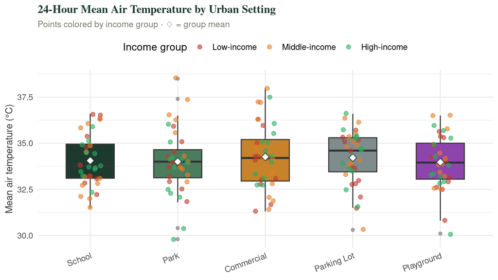

```r
ggplot(log_raw, aes(x = urban_setting, y = mean_air_temperature_c,
                    fill = urban_setting)) +
  geom_boxplot(outlier.alpha = 0.4, outlier.size = 1.5, width = 0.55) +
  geom_jitter(aes(color = demographic_group), width = 0.12,
              alpha = 0.6, size = 2) +
  stat_summary(fun = mean, geom = "point",
               shape = 23, size = 3, fill = "white", color = "#1e3a2f") +
  scale_fill_manual(values  = setting_pal, guide = "none") +
  scale_color_manual(values = income_pal, name = "Income group") +
  labs(title    = "24-Hour Mean Air Temperature by Urban Setting",
       subtitle = "Points colored by income group · ◇ = group mean",
       x = NULL, y = "Mean air temperature (°C)") +
  theme(axis.text.x = element_text(angle = 20, hjust = 1))
```

### 2.2 Temperature by income group across settings

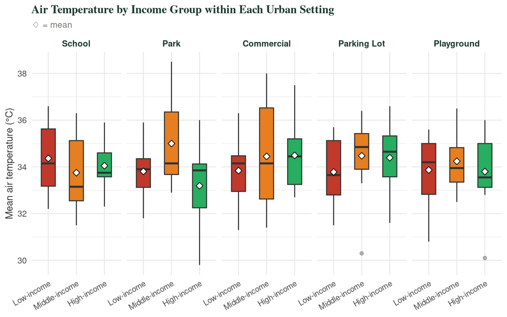

```r
ggplot(log_raw, aes(x = demographic_group, y = mean_air_temperature_c,
                    fill = demographic_group)) +
  geom_boxplot(outlier.alpha = 0.35, width = 0.5) +
  stat_summary(fun = mean, geom = "point",
               shape = 23, size = 2.5, fill = "white") +
  facet_wrap(~ urban_setting, nrow = 1) +
  scale_fill_manual(values = income_pal, guide = "none") +
  labs(title    = "Air Temperature by Income Group within Each Urban Setting",
       subtitle = "◇ = mean",
       x = NULL, y = "Mean air temperature (°C)") +
  theme(axis.text.x = element_text(angle = 30, hjust = 1, size = 9))
```

### 2.3 Canopy cover vs air temperature

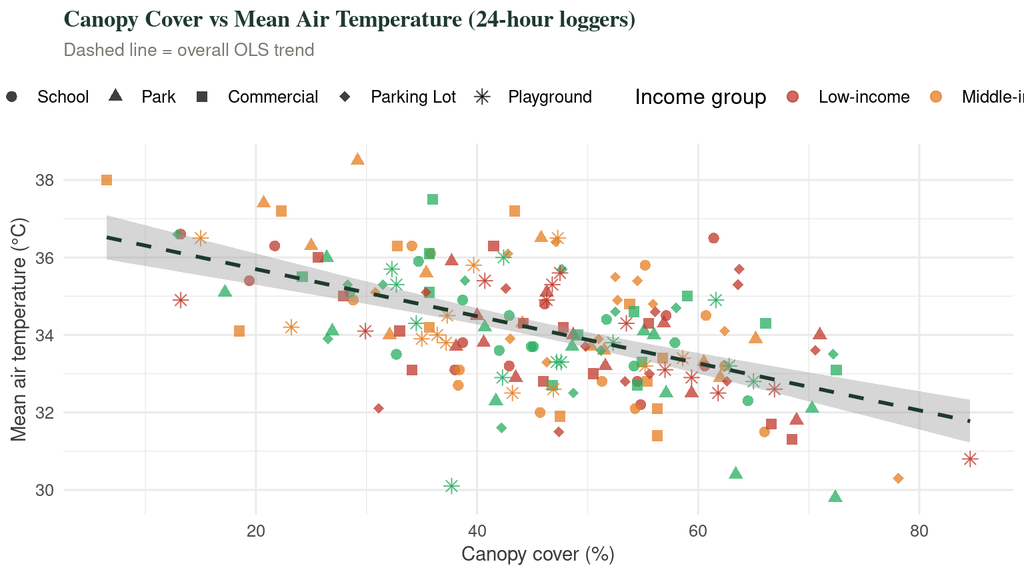

```r
ggplot(log_raw, aes(x = canopy_cover_percent, y = mean_air_temperature_c,
                    color = demographic_group, shape = urban_setting)) +
  geom_point(alpha = 0.75, size = 2.5) +
  geom_smooth(aes(group = 1), method = "lm", se = TRUE,
              color = "#1e3a2f", linewidth = 1, linetype = "dashed") +
  scale_color_manual(values = income_pal, name = "Income group") +
  scale_shape_manual(values = c(16, 17, 15, 18, 8), name = "Urban setting") +
  labs(title    = "Canopy Cover vs Mean Air Temperature (24-hour loggers)",
       subtitle = "Dashed line = overall OLS trend",
       x = "Canopy cover (%)", y = "Mean air temperature (°C)") +
  guides(color = guide_legend(nrow = 1),
         shape = guide_legend(nrow = 1))
```

### 2.4 Canopy cover distribution by income group

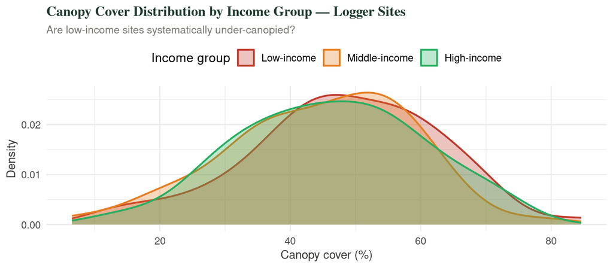

```r
ggplot(log_raw, aes(x = canopy_cover_percent, fill = demographic_group,
                    color = demographic_group)) +
  geom_density(alpha = 0.30, linewidth = 0.8) +
  scale_fill_manual(values  = income_pal, name = "Income group") +
  scale_color_manual(values = income_pal, name = "Income group") +
  labs(title    = "Canopy Cover Distribution by Income Group — Logger Sites",
       subtitle = "Are low-income sites systematically under-canopied?",
       x = "Canopy cover (%)", y = "Density")
```

**📊 What to look for in these plots** If environmental justice patterns are present, you expect: (a) low-income sites cluster at *lower canopy cover* and *higher temperatures*, (b) parking lots and commercial areas show the highest temperatures regardless of income group, and (c) the scatter plot shows a negative slope (more canopy → cooler air).

## 3. Statistical Analysis — Logger Data

### 3.1 One-way ANOVA: does temperature differ by urban setting?

**H₀:** Mean 24-hour air temperature is equal across all five urban settings. **H₁:** At least one setting has a different mean temperature.

```r
aov_setting <- aov(mean_air_temperature_c ~ urban_setting, data = log_raw)
summary(aov_setting)
```

```
##                Df Sum Sq Mean Sq F value Pr(>F)
## urban_setting   4    2.5  0.6173   0.247  0.911
## Residuals     175  436.6  2.4951
```

```r
tidy(aov_setting) |>
  mutate(across(where(is.numeric), ~ round(.x, 4))) |>
  kable(caption = "ANOVA table: air temperature ~ urban setting") |>
  kable_styling(full_width = FALSE)
```

ANOVA table: air temperature ~ urban setting

| term | df | sumsq | meansq | statistic | p.value |
| --- | --- | --- | --- | --- | --- |
| urban_setting | 4 | 2.4691 | 0.6173 | 0.2474 | 0.9109 |
| Residuals | 175 | 436.6408 | 2.4951 | NA | NA |

### 3.2 Post-hoc comparisons (Tukey HSD)

```r
em_setting <- emmeans(aov_setting, ~ urban_setting)
pairs_setting <- pairs(em_setting, adjust = "tukey")
summary(pairs_setting) |>
  as.data.frame() |>
  mutate(across(where(is.numeric), ~ round(.x, 4)),
         sig = case_when(p.value < 0.001 ~ "***",
                         p.value < 0.01  ~ "**",
                         p.value < 0.05  ~ "*",
                         TRUE            ~ "")) |>
  kable(caption = "Tukey HSD pairwise comparisons — urban setting") |>
  kable_styling(full_width = FALSE)
```

Tukey HSD pairwise comparisons — urban setting

| contrast | estimate | SE | df | t.ratio | p.value | sig |
| --- | --- | --- | --- | --- | --- | --- |
| School - Park | 0.0556 | 0.3723 | 175 | 0.1492 | 0.9999 |  |
| School - Commercial | -0.2056 | 0.3723 | 175 | -0.5521 | 0.9816 |  |
| School - Parking Lot | -0.1611 | 0.3723 | 175 | -0.4327 | 0.9926 |  |
| School - Playground | 0.0861 | 0.3723 | 175 | 0.2313 | 0.9994 |  |
| Park - Commercial | -0.2611 | 0.3723 | 175 | -0.7013 | 0.9560 |  |
| Park - Parking Lot | -0.2167 | 0.3723 | 175 | -0.5819 | 0.9776 |  |
| Park - Playground | 0.0306 | 0.3723 | 175 | 0.0821 | 1.0000 |  |
| Commercial - Parking Lot | 0.0444 | 0.3723 | 175 | 0.1194 | 1.0000 |  |
| Commercial - Playground | 0.2917 | 0.3723 | 175 | 0.7834 | 0.9351 |  |
| Parking Lot - Playground | 0.2472 | 0.3723 | 175 | 0.6640 | 0.9638 |  |

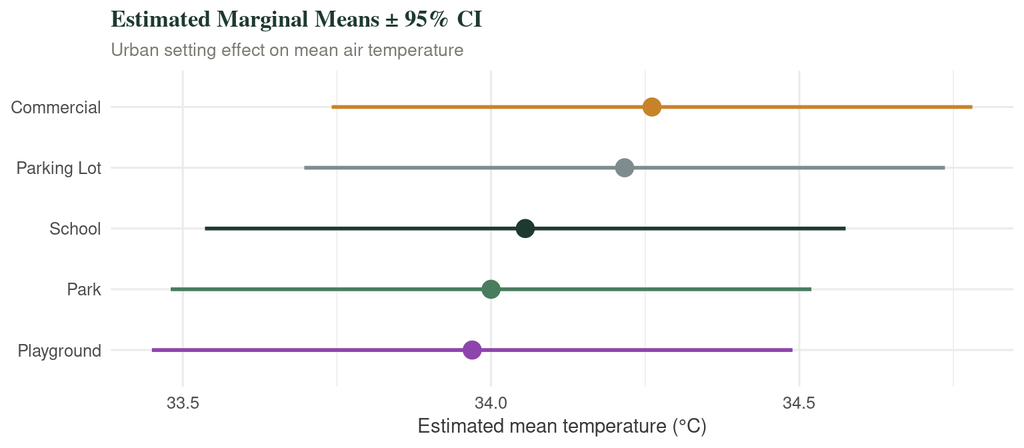

```r
as.data.frame(em_setting) |>
  ggplot(aes(x = reorder(urban_setting, emmean), y = emmean,
             ymin = lower.CL, ymax = upper.CL, color = urban_setting)) +
  geom_pointrange(size = 0.9, linewidth = 1) +
  scale_color_manual(values = setting_pal, guide = "none") +
  coord_flip() +
  labs(title    = "Estimated Marginal Means ± 95% CI",
       subtitle = "Urban setting effect on mean air temperature",
       x = NULL, y = "Estimated mean temperature (°C)")
```

### 3.3 Two-way ANOVA: setting × income group interaction

```r
aov_2way <- aov(mean_air_temperature_c ~ urban_setting * demographic_group,
                data = log_raw)
tidy(aov_2way) |>
  mutate(across(where(is.numeric), ~ round(.x, 4)),
         sig = case_when(p.value < 0.001 ~ "***",
                         p.value < 0.01  ~ "**",
                         p.value < 0.05  ~ "*",
                         TRUE            ~ "")) |>
  kable(caption = "Two-way ANOVA: temperature ~ setting * income group") |>
  kable_styling(full_width = FALSE)
```

Two-way ANOVA: temperature ~ setting * income group

| term | df | sumsq | meansq | statistic | p.value | sig |
| --- | --- | --- | --- | --- | --- | --- |
| urban_setting | 4 | 2.4691 | 0.6173 | 0.2508 | 0.9089 |  |
| demographic_group | 2 | 7.2768 | 3.6384 | 1.4782 | 0.2310 |  |
| urban_setting:demographic_group | 8 | 23.2466 | 2.9058 | 1.1806 | 0.3137 |  |
| Residuals | 165 | 406.1175 | 2.4613 | NA | NA |  |

### 3.4 ANOVA assumptions

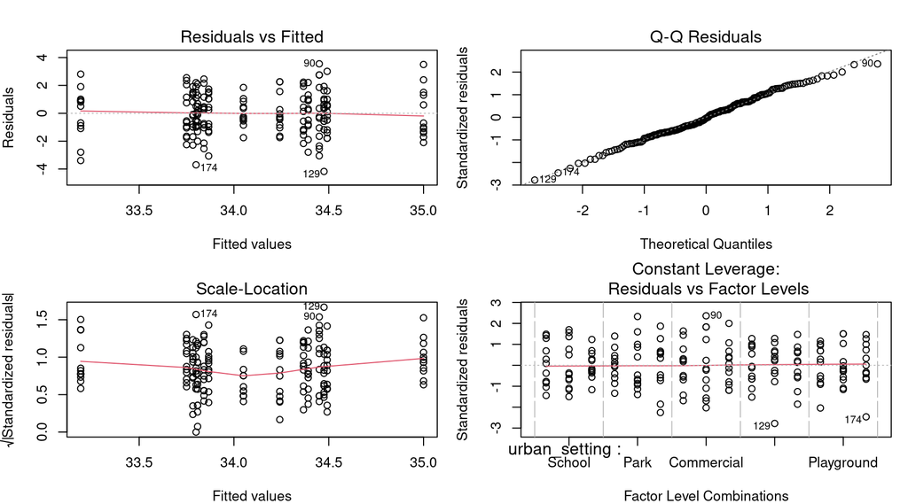

```r
par(mfrow = c(2, 2), mar = c(4, 4, 3, 1))
plot(aov_2way)
```

```r
par(mfrow = c(1, 1))
```

```r
leveneTest(mean_air_temperature_c ~ urban_setting * demographic_group,
           data = log_raw) |>
  tidy() |>
  mutate(across(where(is.numeric), ~ round(.x, 4))) |>
  kable(caption = "Levene's test for homogeneity of variance") |>
  kable_styling(full_width = FALSE)
```

Levene’s test for homogeneity of variance

| statistic | p.value | df | df.residual |
| --- | --- | --- | --- |
| 0.8432 | 0.6215 | 14 | 165 |

### 3.5 Simple linear regression: canopy cover predicts temperature

```r
lm_canopy <- lm(mean_air_temperature_c ~ canopy_cover_percent, data = log_raw)

tidy(lm_canopy) |>
  mutate(across(where(is.numeric), ~ round(.x, 4))) |>
  kable(caption = "OLS regression: air temperature ~ canopy cover (%)") |>
  kable_styling(full_width = FALSE)
```

OLS regression: air temperature ~ canopy cover (%)

| term | estimate | std.error | statistic | p.value |
| --- | --- | --- | --- | --- |
| (Intercept) | 36.9139 | 0.3313 | 111.4096 | 0 |
| canopy_cover_percent | -0.0608 | 0.0068 | -8.8839 | 0 |

```r
glance(lm_canopy) |>
  select(r.squared, adj.r.squared, statistic, p.value, nobs) |>
  mutate(across(where(is.numeric), ~ round(.x, 4))) |>
  kable(caption = "Model fit statistics") |>
  kable_styling(full_width = FALSE)
```

Model fit statistics

| r.squared | adj.r.squared | statistic | p.value | nobs |
| --- | --- | --- | --- | --- |
| 0.3072 | 0.3033 | 78.9228 | 0 | 180 |

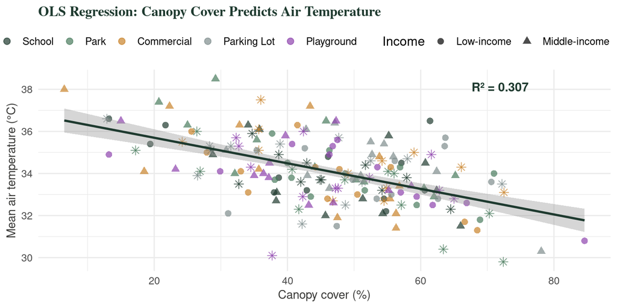

```r
ggplot(log_raw, aes(x = canopy_cover_percent, y = mean_air_temperature_c)) +
  geom_point(aes(color = urban_setting, shape = demographic_group),
             alpha = 0.7, size = 2.5) +
  geom_smooth(method = "lm", se = TRUE,
              color = "#1e3a2f", linewidth = 1) +
  scale_color_manual(values = setting_pal, name = "Setting") +
  scale_shape_manual(values = c(16, 17, 8), name = "Income") +
  annotate("text",
           x = max(log_raw$canopy_cover_percent) * 0.85,
           y = max(log_raw$mean_air_temperature_c) * 0.99,
           label = paste0("R² = ", round(glance(lm_canopy)$r.squared, 3)),
           color = "#1e3a2f", fontface = "bold", size = 4) +
  labs(title    = "OLS Regression: Canopy Cover Predicts Air Temperature",
       x = "Canopy cover (%)", y = "Mean air temperature (°C)")
```

### 3.6 Multiple regression: canopy + setting + income group

```r
lm_multi <- lm(mean_air_temperature_c ~
                 canopy_cover_percent + urban_setting + demographic_group,
               data = log_raw)

tidy(lm_multi) |>
  mutate(
    sig = case_when(p.value < 0.001 ~ "***", p.value < 0.01 ~ "**",
                    p.value < 0.05  ~ "*",   TRUE ~ ""),
    across(where(is.numeric), ~ round(.x, 4))
  ) |>
  kable(caption = "Multiple regression: temperature ~ canopy + setting + income") |>
  kable_styling(full_width = FALSE)
```

Multiple regression: temperature ~ canopy + setting + income

| term | estimate | std.error | statistic | p.value | sig |
| --- | --- | --- | --- | --- | --- |
| (Intercept) | 36.7431 | 0.4160 | 88.3211 | 0.0000 | *** |
| canopy_cover_percent | -0.0610 | 0.0070 | -8.7689 | 0.0000 | *** |
| urban_settingPark | 0.0852 | 0.3100 | 0.2748 | 0.7838 |  |
| urban_settingCommercial | 0.2022 | 0.3096 | 0.6530 | 0.5146 |  |
| urban_settingParking Lot | 0.4023 | 0.3108 | 1.2943 | 0.1973 |  |
| urban_settingPlayground | -0.0458 | 0.3096 | -0.1479 | 0.8826 |  |
| demographic_groupMiddle-income | 0.2248 | 0.2412 | 0.9322 | 0.3525 |  |
| demographic_groupHigh-income | -0.0708 | 0.2402 | -0.2947 | 0.7686 |  |

```r
glance(lm_multi) |>
  select(r.squared, adj.r.squared, AIC, BIC, nobs) |>
  mutate(across(where(is.numeric), ~ round(.x, 3))) |>
  kable(caption = "Multiple regression model fit") |>
  kable_styling(full_width = FALSE)
```

Multiple regression model fit

| r.squared | adj.r.squared | AIC | BIC | nobs |
| --- | --- | --- | --- | --- |
| 0.324 | 0.297 | 618.785 | 647.521 | 180 |

### 3.7 Non-parametric check: Kruskal-Wallis test

```r
kw_setting <- kruskal.test(mean_air_temperature_c ~ urban_setting, data = log_raw)
kw_income  <- kruskal.test(mean_air_temperature_c ~ demographic_group, data = log_raw)

tibble(
  Test      = c("Urban setting", "Income group"),
  Chi_sq    = round(c(kw_setting$statistic, kw_income$statistic), 3),
  df        = c(kw_setting$parameter, kw_income$parameter),
  p_value   = round(c(kw_setting$p.value, kw_income$p.value), 4),
  Sig       = ifelse(c(kw_setting$p.value, kw_income$p.value) < 0.05, "✓", "—")
) |>
  kable(caption = "Kruskal-Wallis tests (non-parametric alternative to ANOVA)") |>
  kable_styling(full_width = FALSE)
```

Kruskal-Wallis tests (non-parametric alternative to ANOVA)

| Test | Chi_sq | df | p_value | Sig |
| --- | --- | --- | --- | --- |
| Urban setting | 1.132 | 4 | 0.8892 | — |
| Income group | 1.856 | 2 | 0.3953 | — |

**📊 Interpreting the logger results** A significant ANOVA F-test tells you that at least one setting has a different mean temperature. The Tukey HSD post-hoc narrows down *which pairs* differ. The regression slope on canopy cover quantifies how much each additional percent of canopy is associated with cooler (or warmer) air. If the income group coefficient is significant in the multiple regression, it suggests that income group predicts temperature even after accounting for canopy and setting — consistent with an environmental justice pattern.

Part II — Dataset 2

## IR Spot Surface Temperature

Handheld IR thermometer · 600 observations · 5 settings × 3 income groups × 40 measurements · Diurnal variation (9 AM – 5 PM)

## 4. Descriptive Statistics — IR Spot Data

### 4.1 Overall summary

```r
ir_raw |>
  summarise(
    N            = n(),
    Mean_surf    = round(mean(ir_surface_temperature_c),   2),
    SD_surf      = round(sd(ir_surface_temperature_c),     2),
    Median_surf  = round(median(ir_surface_temperature_c), 2),
    IQR_surf     = round(IQR(ir_surface_temperature_c),    2),
    Min_surf     = round(min(ir_surface_temperature_c),    2),
    Max_surf     = round(max(ir_surface_temperature_c),    2),
    Skewness     = round(moments::skewness(ir_surface_temperature_c), 3),
    Mean_canopy  = round(mean(canopy_cover_percent), 1),
    Hour_range   = paste(min(measurement_hour), "–", max(measurement_hour))
  ) |>
  kable(caption = "Overall descriptive statistics — IR surface temperature") |>
  kable_styling(full_width = FALSE)
```

Overall descriptive statistics — IR surface temperature

| N | Mean_surf | SD_surf | Median_surf | IQR_surf | Min_surf | Max_surf | Skewness | Mean_canopy | Hour_range |
| --- | --- | --- | --- | --- | --- | --- | --- | --- | --- |
| 600 | 42.09 | 5.26 | 42.15 | 6.93 | 22.7 | 55.3 | -0.135 | 40.7 | 9 – 17 |

### 4.2 By urban setting and income group

```r
ir_raw |>
  group_by(urban_setting, demographic_group) |>
  summarise(
    N    = n(),
    Mean = round(mean(ir_surface_temperature_c),   2),
    SD   = round(sd(ir_surface_temperature_c),     2),
    Med  = round(median(ir_surface_temperature_c), 2),
    Max  = round(max(ir_surface_temperature_c),    2),
    .groups = "drop"
  ) |>
  rename(`Urban setting` = urban_setting, `Income group` = demographic_group,
         `Mean (°C)` = Mean, `Max (°C)` = Max) |>
  kable(caption = "IR surface temperature summary by urban setting and income group") |>
  kable_styling(full_width = TRUE) |>
  column_spec(1, bold = TRUE)
```

IR surface temperature summary by urban setting and income group

| Urban setting | Income group | N | Mean (°C) | SD | Med | Max (°C) |
| --- | --- | --- | --- | --- | --- | --- |
| School | Low-income | 40 | 41.47 | 5.44 | 41.00 | 53.7 |
| School | Middle-income | 40 | 41.42 | 7.06 | 42.10 | 52.9 |
| School | High-income | 40 | 41.45 | 5.35 | 42.45 | 54.1 |
| Park | Low-income | 40 | 41.52 | 5.27 | 41.35 | 52.3 |
| Park | Middle-income | 40 | 42.97 | 4.18 | 43.45 | 49.7 |
| Park | High-income | 40 | 41.88 | 4.49 | 41.60 | 51.2 |
| Commercial | Low-income | 40 | 43.16 | 4.85 | 42.40 | 50.9 |
| Commercial | Middle-income | 40 | 42.65 | 4.01 | 42.55 | 50.6 |
| Commercial | High-income | 40 | 41.59 | 5.32 | 41.00 | 51.6 |
| Parking Lot | Low-income | 40 | 42.79 | 5.53 | 43.40 | 53.8 |
| Parking Lot | Middle-income | 40 | 42.18 | 6.07 | 42.70 | 54.8 |
| Parking Lot | High-income | 40 | 42.34 | 5.32 | 41.35 | 54.3 |
| Playground | Low-income | 40 | 41.95 | 5.46 | 42.30 | 55.3 |
| Playground | Middle-income | 40 | 41.17 | 5.66 | 41.20 | 54.0 |
| Playground | High-income | 40 | 42.83 | 4.42 | 42.60 | 53.4 |

### 4.3 By time of day

```r
ir_raw |>
  group_by(time_of_day, urban_setting) |>
  summarise(
    N    = n(),
    Mean = round(mean(ir_surface_temperature_c), 2),
    SD   = round(sd(ir_surface_temperature_c),   2),
    .groups = "drop"
  ) |>
  pivot_wider(names_from = time_of_day,
              values_from = c(Mean, SD),
              names_glue  = "{time_of_day}_{.value}") |>
  kable(caption = "Mean IR surface temperature (°C) by time of day and urban setting") |>
  kable_styling(full_width = TRUE)
```

Mean IR surface temperature (°C) by time of day and urban setting

| urban_setting | N | Morning (9–11)_Mean | Midday (12–14)_Mean | Afternoon (15–17)_Mean | Morning (9–11)_SD | Midday (12–14)_SD | Afternoon (15–17)_SD |
| --- | --- | --- | --- | --- | --- | --- | --- |
| School | 42 | 42.12 | 41.11 | NA | 4.81 | 5.83 | NA |
| Park | 35 | 42.98 | NA | NA | 5.15 | NA | NA |
| Commercial | 42 | 42.37 | NA | NA | 4.95 | NA | NA |
| Parking Lot | 40 | 43.04 | NA | NA | 6.04 | NA | NA |
| Playground | 37 | 41.15 | NA | NA | 5.12 | NA | NA |
| Park | 51 | NA | 42.43 | NA | NA | 4.45 | NA |
| Commercial | 37 | NA | 43.27 | NA | NA | 5.01 | NA |
| Parking Lot | 35 | NA | 42.28 | NA | NA | 5.69 | NA |
| Playground | 49 | NA | 42.02 | NA | NA | 5.42 | NA |
| School | 36 | NA | NA | 41.05 | NA | NA | 7.26 |
| Park | 34 | NA | NA | 40.79 | NA | NA | 4.31 |
| Commercial | 41 | NA | NA | 41.85 | NA | NA | 4.35 |
| Parking Lot | 45 | NA | NA | 42.03 | NA | NA | 5.22 |
| Playground | 34 | NA | NA | 42.83 | NA | NA | 5.02 |

### 4.4 Normality check

```r
ir_raw |>
  group_by(urban_setting) |>
  summarise(
    n    = n(),
    W    = round(shapiro.test(sample(ir_surface_temperature_c,
                                     min(n(), 5000)))$statistic, 4),
    p    = round(shapiro.test(sample(ir_surface_temperature_c,
                                     min(n(), 5000)))$p.value, 4),
    Skew = round(moments::skewness(ir_surface_temperature_c), 3),
    .groups = "drop"
  ) |>
  mutate(Normal = ifelse(p > 0.05, "Yes", "No")) |>
  kable(caption = "Shapiro-Wilk normality test per urban setting (IR data)") |>
  kable_styling(full_width = FALSE)
```

Shapiro-Wilk normality test per urban setting (IR data)

| urban_setting | n | W | p | Skew | Normal |
| --- | --- | --- | --- | --- | --- |
| School | 120 | 0.9917 | 0.6960 | -0.176 | Yes |
| Park | 120 | 0.9889 | 0.4434 | -0.155 | Yes |
| Commercial | 120 | 0.9808 | 0.0852 | -0.285 | Yes |
| Parking Lot | 120 | 0.9860 | 0.2527 | 0.194 | Yes |
| Playground | 120 | 0.9857 | 0.2383 | -0.230 | Yes |

## 5. Visualization — IR Spot Data

### 5.1 Surface temperature distributions

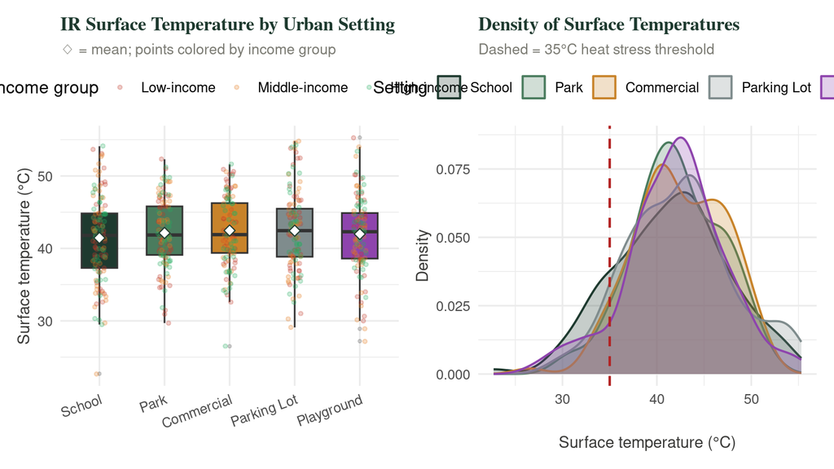

```r
p_box2 <- ggplot(ir_raw,
                 aes(x = urban_setting, y = ir_surface_temperature_c,
                     fill = urban_setting)) +
  geom_boxplot(outlier.alpha = 0.2, outlier.size = 0.8, width = 0.55) +
  geom_jitter(aes(color = demographic_group), width = 0.1,
              alpha = 0.25, size = 1) +
  stat_summary(fun = mean, geom = "point",
               shape = 23, size = 2.5, fill = "white", color = "#1e3a2f") +
  scale_fill_manual(values  = setting_pal, guide = "none") +
  scale_color_manual(values = income_pal,  name  = "Income group") +
  labs(title = "IR Surface Temperature by Urban Setting",
       subtitle = "◇ = mean; points colored by income group",
       x = NULL, y = "Surface temperature (°C)") +
  theme(axis.text.x = element_text(angle = 20, hjust = 1))

p_dens2 <- ggplot(ir_raw,
                  aes(x = ir_surface_temperature_c, fill = urban_setting,
                      color = urban_setting)) +
  geom_density(alpha = 0.25, linewidth = 0.7) +
  geom_vline(xintercept = 35, linetype = "dashed",
             color = "firebrick", linewidth = 0.8) +
  scale_fill_manual(values  = setting_pal, name = "Setting") +
  scale_color_manual(values = setting_pal, name = "Setting") +
  labs(title    = "Density of Surface Temperatures",
       subtitle = "Dashed = 35°C heat stress threshold",
       x = "Surface temperature (°C)", y = "Density")

p_box2 + p_dens2
```

### 5.2 Diurnal pattern by urban setting

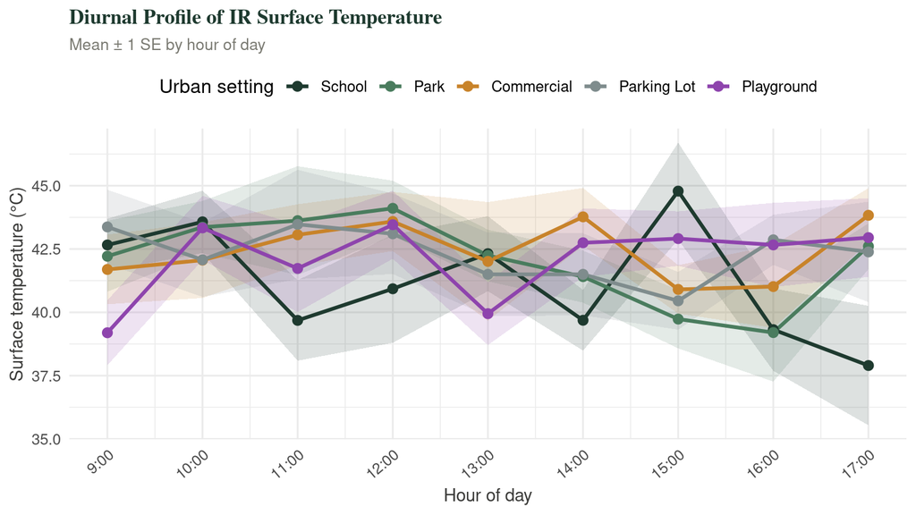

```r
ir_raw |>
  group_by(urban_setting, measurement_hour) |>
  summarise(
    mean_temp = mean(ir_surface_temperature_c),
    se_temp   = sd(ir_surface_temperature_c) / sqrt(n()),
    .groups   = "drop"
  ) |>
  ggplot(aes(x = measurement_hour, y = mean_temp,
             color = urban_setting, fill = urban_setting)) +
  geom_ribbon(aes(ymin = mean_temp - se_temp, ymax = mean_temp + se_temp),
              alpha = 0.15, color = NA) +
  geom_line(linewidth = 1.1) +
  geom_point(size = 2.5) +
  scale_color_manual(values = setting_pal, name = "Urban setting") +
  scale_fill_manual(values  = setting_pal, guide = "none") +
  scale_x_continuous(breaks = 9:17,
                     labels = paste0(9:17, ":00")) +
  labs(title    = "Diurnal Profile of IR Surface Temperature",
       subtitle = "Mean ± 1 SE by hour of day",
       x = "Hour of day", y = "Surface temperature (°C)") +
  theme(axis.text.x = element_text(angle = 40, hjust = 1))
```

### 5.3 Diurnal pattern by income group

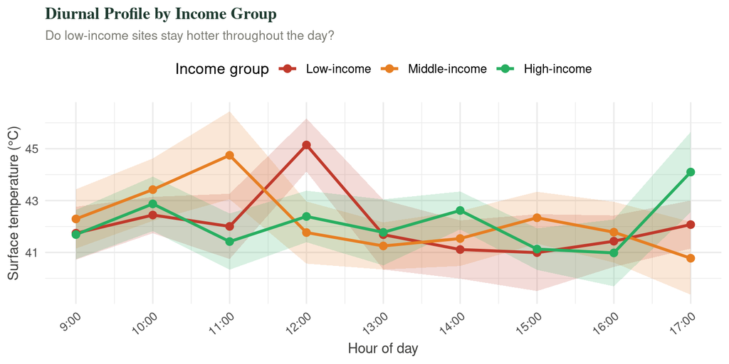

```r
ir_raw |>
  group_by(demographic_group, measurement_hour) |>
  summarise(
    mean_temp = mean(ir_surface_temperature_c),
    se_temp   = sd(ir_surface_temperature_c) / sqrt(n()),
    .groups   = "drop"
  ) |>
  ggplot(aes(x = measurement_hour, y = mean_temp,
             color = demographic_group, fill = demographic_group)) +
  geom_ribbon(aes(ymin = mean_temp - se_temp, ymax = mean_temp + se_temp),
              alpha = 0.18, color = NA) +
  geom_line(linewidth = 1.1) +
  geom_point(size = 2.5) +
  scale_color_manual(values = income_pal, name = "Income group") +
  scale_fill_manual(values  = income_pal, guide = "none") +
  scale_x_continuous(breaks = 9:17, labels = paste0(9:17, ":00")) +
  labs(title    = "Diurnal Profile by Income Group",
       subtitle = "Do low-income sites stay hotter throughout the day?",
       x = "Hour of day", y = "Surface temperature (°C)") +
  theme(axis.text.x = element_text(angle = 40, hjust = 1))
```

### 5.4 Canopy cover vs surface temperature by time of day

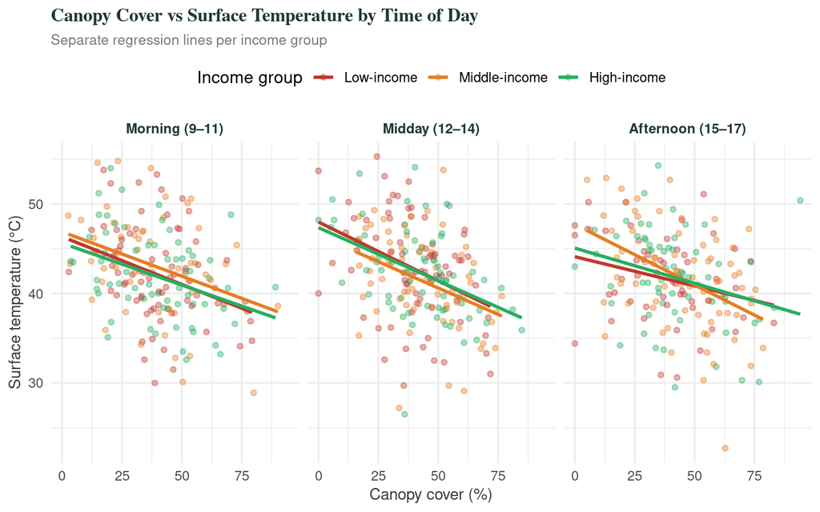

```r
ggplot(ir_raw,
       aes(x = canopy_cover_percent, y = ir_surface_temperature_c,
           color = demographic_group)) +
  geom_point(alpha = 0.4, size = 1.5) +
  geom_smooth(method = "lm", se = FALSE, linewidth = 1.1) +
  facet_wrap(~ time_of_day) +
  scale_color_manual(values = income_pal, name = "Income group") +
  labs(title    = "Canopy Cover vs Surface Temperature by Time of Day",
       subtitle = "Separate regression lines per income group",
       x = "Canopy cover (%)", y = "Surface temperature (°C)") +
  guides(color = guide_legend(nrow = 1))
```

### 5.5 Income group × urban setting heatmap

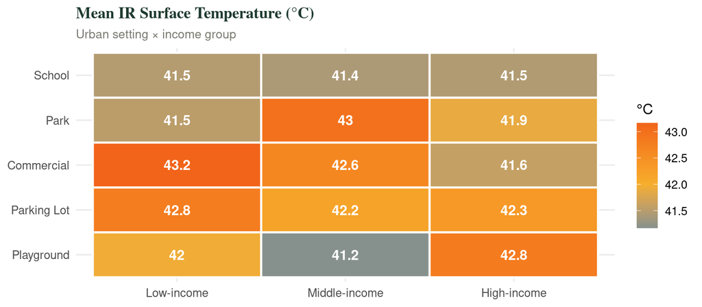

```r
ir_raw |>
  group_by(urban_setting, demographic_group) |>
  summarise(mean_temp = mean(ir_surface_temperature_c), .groups = "drop") |>
  ggplot(aes(x = demographic_group, y = fct_rev(urban_setting),
             fill = mean_temp)) +
  geom_tile(color = "white", linewidth = 0.8) +
  geom_text(aes(label = round(mean_temp, 1)),
            color = "white", fontface = "bold", size = 4) +
  scale_fill_gradient2(low = "#2e86ab", mid = "#f6ae2d", high = "#f26419",
                       midpoint = 42, name = "°C") +
  labs(title = "Mean IR Surface Temperature (°C)",
       subtitle = "Urban setting × income group",
       x = NULL, y = NULL) +
  theme(legend.position = "right")
```

## 6. Statistical Analysis — IR Spot Data

### 6.1 One-way ANOVA: surface temperature by urban setting

```r
aov2_setting <- aov(ir_surface_temperature_c ~ urban_setting, data = ir_raw)
tidy(aov2_setting) |>
  mutate(across(where(is.numeric), ~ round(.x, 4)),
         sig = case_when(p.value < 0.001 ~ "***", p.value < 0.01 ~ "**",
                         p.value < 0.05 ~ "*", TRUE ~ "")) |>
  kable(caption = "ANOVA: IR surface temperature ~ urban setting") |>
  kable_styling(full_width = FALSE)
```

ANOVA: IR surface temperature ~ urban setting

| term | df | sumsq | meansq | statistic | p.value | sig |
| --- | --- | --- | --- | --- | --- | --- |
| urban_setting | 4 | 83.1704 | 20.7926 | 0.75 | 0.5583 |  |
| Residuals | 595 | 16496.1428 | 27.7246 | NA | NA |  |

### 6.2 One-way ANOVA: surface temperature by income group

```r
aov2_income <- aov(ir_surface_temperature_c ~ demographic_group, data = ir_raw)
tidy(aov2_income) |>
  mutate(across(where(is.numeric), ~ round(.x, 4)),
         sig = case_when(p.value < 0.001 ~ "***", p.value < 0.01 ~ "**",
                         p.value < 0.05 ~ "*", TRUE ~ "")) |>
  kable(caption = "ANOVA: IR surface temperature ~ income group") |>
  kable_styling(full_width = FALSE)
```

ANOVA: IR surface temperature ~ income group

| term | df | sumsq | meansq | statistic | p.value | sig |
| --- | --- | --- | --- | --- | --- | --- |
| demographic_group | 2 | 2.6889 | 1.3445 | 0.0484 | 0.9527 |  |
| Residuals | 597 | 16576.6243 | 27.7665 | NA | NA |  |

### 6.3 Tukey HSD post-hoc: urban setting

```r
em2 <- emmeans(aov2_setting, ~ urban_setting)
pairs(em2, adjust = "tukey") |>
  as.data.frame() |>
  mutate(across(where(is.numeric), ~ round(.x, 4)),
         sig = case_when(p.value < 0.001 ~ "***", p.value < 0.01 ~ "**",
                         p.value < 0.05 ~ "*", TRUE ~ "")) |>
  kable(caption = "Tukey HSD: urban setting pairwise comparisons (IR data)") |>
  kable_styling(full_width = FALSE)
```

Tukey HSD: urban setting pairwise comparisons (IR data)

| contrast | estimate | SE | df | t.ratio | p.value | sig |
| --- | --- | --- | --- | --- | --- | --- |
| School - Park | -0.6808 | 0.6798 | 595 | -1.0016 | 0.8546 |  |
| School - Commercial | -1.0225 | 0.6798 | 595 | -1.5042 | 0.5601 |  |
| School - Parking Lot | -0.9942 | 0.6798 | 595 | -1.4625 | 0.5873 |  |
| School - Playground | -0.5383 | 0.6798 | 595 | -0.7919 | 0.9329 |  |
| Park - Commercial | -0.3417 | 0.6798 | 595 | -0.5026 | 0.9871 |  |
| Park - Parking Lot | -0.3133 | 0.6798 | 595 | -0.4609 | 0.9907 |  |
| Park - Playground | 0.1425 | 0.6798 | 595 | 0.2096 | 0.9996 |  |
| Commercial - Parking Lot | 0.0283 | 0.6798 | 595 | 0.0417 | 1.0000 |  |
| Commercial - Playground | 0.4842 | 0.6798 | 595 | 0.7123 | 0.9537 |  |
| Parking Lot - Playground | 0.4558 | 0.6798 | 595 | 0.6706 | 0.9627 |  |

### 6.4 Kruskal-Wallis: time of day effect

```r
kw_tod <- kruskal.test(ir_surface_temperature_c ~ time_of_day, data = ir_raw)

tibble(
  Test    = "Time of day (Morning / Midday / Afternoon)",
  Chi_sq  = round(kw_tod$statistic, 3),
  df      = kw_tod$parameter,
  p_value = round(kw_tod$p.value,   4),
  Sig     = ifelse(kw_tod$p.value < 0.05, "✓", "—")
) |>
  kable(caption = "Kruskal-Wallis: does surface temperature vary by time of day?") |>
  kable_styling(full_width = FALSE)
```

Kruskal-Wallis: does surface temperature vary by time of day?

| Test | Chi_sq | df | p_value | Sig |
| --- | --- | --- | --- | --- |
| Time of day (Morning / Midday / Afternoon) | 0.872 | 2 | 0.6465 | — |

### 6.5 Simple regression: canopy cover predicts surface temperature

```r
lm2_canopy <- lm(ir_surface_temperature_c ~ canopy_cover_percent, data = ir_raw)

tidy(lm2_canopy) |>
  mutate(across(where(is.numeric), ~ round(.x, 4))) |>
  kable(caption = "OLS regression: surface temperature ~ canopy cover (%)") |>
  kable_styling(full_width = FALSE)
```

OLS regression: surface temperature ~ canopy cover (%)

| term | estimate | std.error | statistic | p.value |
| --- | --- | --- | --- | --- |
| (Intercept) | 46.4157 | 0.4913 | 94.4739 | 0 |
| canopy_cover_percent | -0.1061 | 0.0110 | -9.6344 | 0 |

```r
glance(lm2_canopy) |>
  select(r.squared, adj.r.squared, statistic, p.value, nobs) |>
  mutate(across(where(is.numeric), ~ round(.x, 4))) |>
  kable(caption = "Model fit (simple regression)") |>
  kable_styling(full_width = FALSE)
```

Model fit (simple regression)

| r.squared | adj.r.squared | statistic | p.value | nobs |
| --- | --- | --- | --- | --- |
| 0.1344 | 0.1329 | 92.8213 | 0 | 600 |

### 6.6 Multiple regression: canopy + hour + setting + income

```r
lm2_multi <- lm(ir_surface_temperature_c ~
                  canopy_cover_percent +
                  measurement_hour     +
                  urban_setting        +
                  demographic_group,
                data = ir_raw)

tidy(lm2_multi) |>
  mutate(
    sig = case_when(p.value < 0.001 ~ "***", p.value < 0.01 ~ "**",
                    p.value < 0.05  ~ "*",   TRUE ~ ""),
    across(where(is.numeric), ~ round(.x, 4))
  ) |>
  kable(caption = "Multiple regression: surface temp ~ canopy + hour + setting + income") |>
  kable_styling(full_width = FALSE)
```

Multiple regression: surface temp ~ canopy + hour + setting + income

| term | estimate | std.error | statistic | p.value | sig |
| --- | --- | --- | --- | --- | --- |
| (Intercept) | 46.9505 | 1.1991 | 39.1562 | 0.0000 | *** |
| canopy_cover_percent | -0.1060 | 0.0111 | -9.5849 | 0.0000 | *** |
| measurement_hour | -0.0881 | 0.0780 | -1.1291 | 0.2593 |  |
| urban_settingPark | 0.4759 | 0.6344 | 0.7501 | 0.4535 |  |
| urban_settingCommercial | 0.9032 | 0.6339 | 1.4247 | 0.1548 |  |
| urban_settingParking Lot | 1.0048 | 0.6339 | 1.5850 | 0.1135 |  |
| urban_settingPlayground | 0.3380 | 0.6341 | 0.5330 | 0.5943 |  |
| demographic_groupMiddle-income | 0.1390 | 0.4921 | 0.2826 | 0.7776 |  |
| demographic_groupHigh-income | 0.0277 | 0.4913 | 0.0563 | 0.9551 |  |

```r
glance(lm2_multi) |>
  select(r.squared, adj.r.squared, AIC, BIC, nobs) |>
  mutate(across(where(is.numeric), ~ round(.x, 3))) |>
  kable(caption = "Multiple regression model fit (IR data)") |>
  kable_styling(full_width = FALSE)
```

Multiple regression model fit (IR data)

| r.squared | adj.r.squared | AIC | BIC | nobs |
| --- | --- | --- | --- | --- |
| 0.141 | 0.129 | 3622.847 | 3666.816 | 600 |

### 6.7 Model comparison: does adding hour improve fit?

```r
lm2_base   <- lm(ir_surface_temperature_c ~
                   canopy_cover_percent + urban_setting + demographic_group,
                 data = ir_raw)
lm2_withhour <- lm2_multi   # already includes measurement_hour

anova(lm2_base, lm2_withhour) |>
  tidy() |>
  mutate(across(where(is.numeric), ~ round(.x, 4))) |>
  kable(caption = "Likelihood ratio test: does measurement hour improve model fit?") |>
  kable_styling(full_width = FALSE)
```

Likelihood ratio test: does measurement hour improve model fit?

| term | df.residual | rss | df | sumsq | statistic | p.value |
| --- | --- | --- | --- | --- | --- | --- |
| ir_surface_temperature_c ~ canopy_cover_percent + urban_setting + demographic_group | 592 | 14270.53 | NA | NA | NA | NA |
| ir_surface_temperature_c ~ canopy_cover_percent + measurement_hour + urban_setting + demographic_group | 591 | 14239.82 | 1 | 30.716 | 1.2748 | 0.2593 |

```r
tibble(
  Model   = c("Base (canopy + setting + income)",
              "Full (+ measurement hour)"),
  AIC     = round(c(AIC(lm2_base), AIC(lm2_multi)), 2),
  adj_R2  = round(c(summary(lm2_base)$adj.r.squared,
                    summary(lm2_multi)$adj.r.squared), 4)
) |>
  kable(caption = "AIC and adjusted R² comparison") |>
  kable_styling(full_width = FALSE)
```

AIC and adjusted R² comparison

| Model | AIC | adj_R2 |
| --- | --- | --- |
| Base (canopy + setting + income) | 3622.14 | 0.1291 |
| Full (+ measurement hour) | 3622.85 | 0.1295 |

### 6.8 Interaction: does canopy effect vary by income group?

```r
lm2_interact <- lm(ir_surface_temperature_c ~
                     canopy_cover_percent * demographic_group +
                     measurement_hour + urban_setting,
                   data = ir_raw)

tidy(lm2_interact) |>
  filter(str_detect(term, "canopy|demographic|:")) |>
  mutate(
    sig = case_when(p.value < 0.001 ~ "***", p.value < 0.01 ~ "**",
                    p.value < 0.05  ~ "*",   TRUE ~ ""),
    across(where(is.numeric), ~ round(.x, 4))
  ) |>
  kable(caption = "Interaction model: canopy × income group coefficients (selected terms)") |>
  kable_styling(full_width = FALSE)
```

Interaction model: canopy × income group coefficients (selected terms)

| term | estimate | std.error | statistic | p.value | sig |
| --- | --- | --- | --- | --- | --- |
| canopy_cover_percent | -0.1005 | 0.0199 | -5.0441 | 0.0000 | *** |
| demographic_groupMiddle-income | 0.9503 | 1.2138 | 0.7829 | 0.4340 |  |
| demographic_groupHigh-income | -0.1478 | 1.2140 | -0.1217 | 0.9031 |  |
| canopy_cover_percent:demographic_groupMiddle-income | -0.0199 | 0.0275 | -0.7226 | 0.4702 |  |
| canopy_cover_percent:demographic_groupHigh-income | 0.0040 | 0.0275 | 0.1458 | 0.8841 |  |

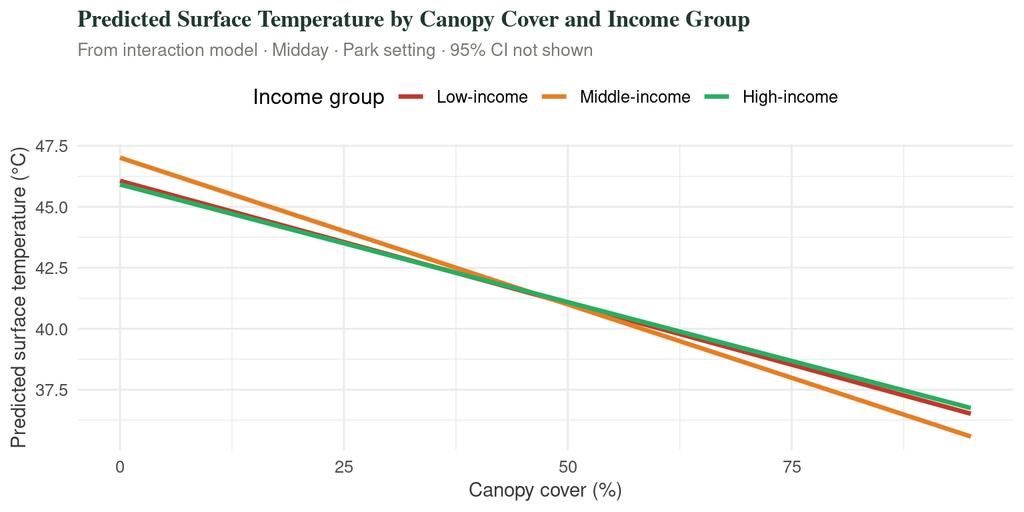

```r
newdata <- expand.grid(
  canopy_cover_percent = seq(0, 95, by = 5),
  demographic_group    = income_lvl,
  measurement_hour     = 13,          # midday
  urban_setting        = "Park"       # reference setting
) |>
  mutate(demographic_group = factor(demographic_group, levels = income_lvl),
         urban_setting     = factor(urban_setting,     levels = setting_lvl))

newdata$pred_temp <- predict(lm2_interact, newdata = newdata)

ggplot(newdata, aes(x = canopy_cover_percent, y = pred_temp,
                   color = demographic_group)) +
  geom_line(linewidth = 1.2) +
  scale_color_manual(values = income_pal, name = "Income group") +
  labs(title    = "Predicted Surface Temperature by Canopy Cover and Income Group",
       subtitle = "From interaction model · Midday · Park setting · 95% CI not shown",
       x = "Canopy cover (%)", y = "Predicted surface temperature (°C)")
```

### 6.9 Residual diagnostics

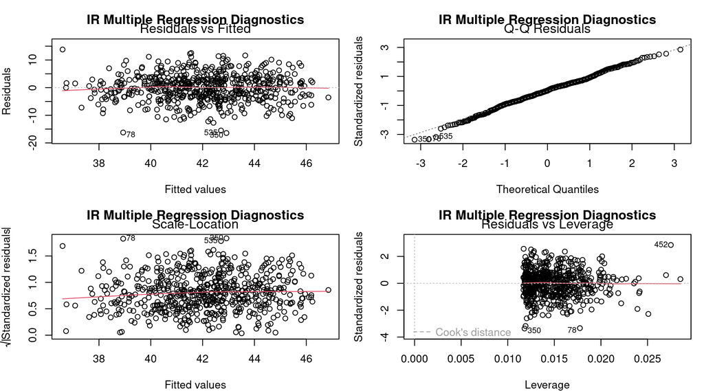

```r
par(mfrow = c(2, 2), mar = c(4, 4, 3, 1))
plot(lm2_multi, main = "IR Multiple Regression Diagnostics")
```

```r
par(mfrow = c(1, 1))
```

**📊 Key interpretations — IR surface temperature** The multiple regression coefficient on `canopy_cover_percent` gives the average surface temperature reduction (°C) per additional percent of canopy, *holding hour, setting, and income constant*. A significant interaction between canopy and income group would mean the canopy benefit is distributed unequally — e.g., the cooling effect per percent canopy differs between high- and low-income sites. Compare model AIC to confirm whether adding measurement hour materially improves fit.

## Synthesis

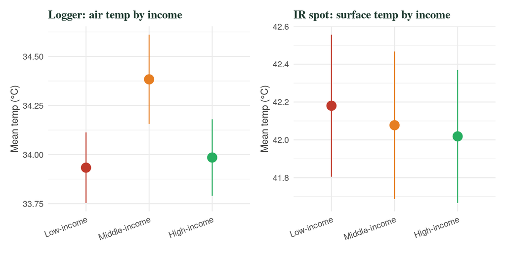

```r
# Side-by-side: income group means for both instruments
p_log_inc <- log_raw |>
  group_by(demographic_group) |>
  summarise(mean = mean(mean_air_temperature_c),
            se   = sd(mean_air_temperature_c) / sqrt(n()), .groups = "drop") |>
  ggplot(aes(x = demographic_group, y = mean, ymin = mean - se, ymax = mean + se,
             color = demographic_group)) +
  geom_pointrange(size = 1) +
  scale_color_manual(values = income_pal, guide = "none") +
  labs(title = "Logger: air temp by income", x = NULL, y = "Mean temp (°C)") +
  theme(axis.text.x = element_text(angle = 20, hjust = 1))

p_ir_inc <- ir_raw |>
  group_by(demographic_group) |>
  summarise(mean = mean(ir_surface_temperature_c),
            se   = sd(ir_surface_temperature_c) / sqrt(n()), .groups = "drop") |>
  ggplot(aes(x = demographic_group, y = mean, ymin = mean - se, ymax = mean + se,
             color = demographic_group)) +
  geom_pointrange(size = 1) +
  scale_color_manual(values = income_pal, guide = "none") +
  labs(title = "IR spot: surface temp by income", x = NULL, y = "Mean temp (°C)") +
  theme(axis.text.x = element_text(angle = 20, hjust = 1))

p_log_inc + p_ir_inc
```

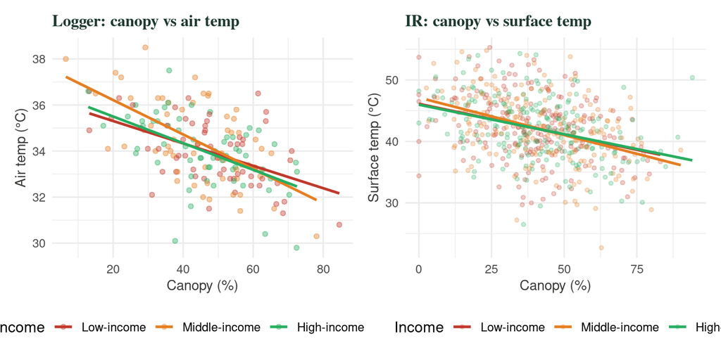

```r
# Canopy slopes comparison
p_slope_log <- ggplot(log_raw,
                      aes(x = canopy_cover_percent,
                          y = mean_air_temperature_c,
                          color = demographic_group)) +
  geom_point(alpha = 0.4, size = 1.5) +
  geom_smooth(method = "lm", se = FALSE, linewidth = 1) +
  scale_color_manual(values = income_pal, name = "Income") +
  labs(title = "Logger: canopy vs air temp",
       x = "Canopy (%)", y = "Air temp (°C)")

p_slope_ir <- ggplot(ir_raw,
                     aes(x = canopy_cover_percent,
                         y = ir_surface_temperature_c,
                         color = demographic_group)) +
  geom_point(alpha = 0.25, size = 1.2) +
  geom_smooth(method = "lm", se = FALSE, linewidth = 1) +
  scale_color_manual(values = income_pal, name = "Income") +
  labs(title = "IR: canopy vs surface temp",
       x = "Canopy (%)", y = "Surface temp (°C)")

p_slope_log + p_slope_ir +
  plot_layout(guides = "collect") &
  theme(legend.position = "bottom")
```